# Power generation prediction

| Author | Yrieix Leprince |
| --- | --- |
| Date | April 2018. |
| Context | Work done in order to candidate at Craft AI (http://www.craft.ai/) |
| Datasets | https://www.dropbox.com/s/pqenrr2mcvl0hk9/GEFCom2014.zip?dl=0 |
| Goal | Predict the **power generation** for 10 wind farms given wind zonal and meridional components (at 10 and 100 meters). |

The following notebook is based on the *GEFCom2014_Data/Wind/task01/Task1_W_Zone1_10/* dataset.

```python
from time import time
import pandas as pd

import numpy as np
from numpy.linalg import norm

import matplotlib
import matplotlib.pyplot as plt
```

```python
matplotlib.rcParams["figure.figsize"] = (20, 8)
matplotlib.rcParams['agg.path.chunksize'] = 10000
FONT = {'family': 'sans-serif', 'weight': 'normal', 'size': 16}
```

## 0. Load Data

```python
path = '../data/GEFCom2014_Data/Wind/task01/Task1_W_Zone1_10/'
```

```python
# Load data
task01 = pd.read_csv(path + 'Task1_W_Zone1.csv')
for i in range(2, 11):
    task01 = task01.append(pd.read_csv(path + 'Task1_W_Zone{}.csv'.format(i)))
```

## 1. Data exploration

We have a column `TIMESTAMP` giving the record timestamp. We choose to set this column as index in order to work with timeseries.

```python
# Set TIMESTAMP as index
task01.TIMESTAMP = pd.to_datetime(task01.TIMESTAMP) - pd.to_timedelta(1, unit='h')
task01.set_index(['TIMESTAMP'], drop=True, inplace=True)
task01.sort_index(ascending=True, inplace=True)

task01.head()
```

| TIMESTAMP | ZONEID | TARGETVAR | U10 | V10 | U100 | V100 |
| --- | --- | --- | --- | --- | --- | --- |
| 2012-01-01 | 1 | 0.000000 | 2.124600 | -2.681966 | 2.864280 | -3.666076 |
| 2012-01-01 | 4 | 0.378229 | 0.534894 | -3.660243 | 0.765355 | -4.486657 |
| 2012-01-01 | 5 | 0.273678 | 0.534894 | -3.660243 | 0.765355 | -4.486657 |
| 2012-01-01 | 2 | 0.596273 | -0.171642 | -5.466031 | -0.112594 | -7.101347 |
| 2012-01-01 | 10 | 0.594361 | 1.655790 | -4.649593 | 2.024257 | -5.992232 |

Now we have our dataframe indexed on timestamps. We have 24 records per day (every hour) for each of the 10 wind farms, from the 2012-01-01 to the 2012-09-30. Our dataframe contains the following columns:

| Column | Description |
| --- | --- |
| `ZONEID` | Wind farm id. |
| `TARGETVAR` | Wind farm power generation, normalized by its nominal capacity. |
| `U10` | Zonal wind component, measured at 10 meters above ground level. |
| `V10` | Meridional wind component, measured at 10 meters above ground level. |
| `U100` | Zonal wind component, measured at 100 meters above ground level. |
| `V100` | Meridional wind component, measured at 100 meters above ground level. |

### 1.1. Trends analysis

Graphs below show the `TARGETVAR` trends over time.

```python
trends = {
    'daily'     : 24      ,#ie. 24 hours/records a day
    'weekly'    : 24*7    ,#ie. 24 hours/records a day * 7  days
    'monthly'   : 24*30   ,#ie. 24h * 30 days
    'quarterly' : 24*30*3 ,#ie. 24h * 30d * 3 months
}
```

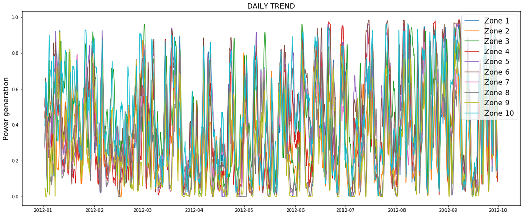

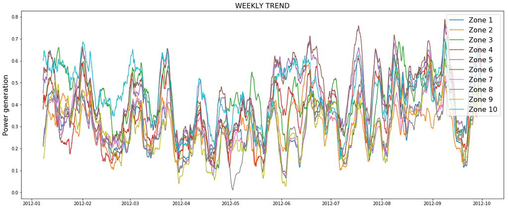

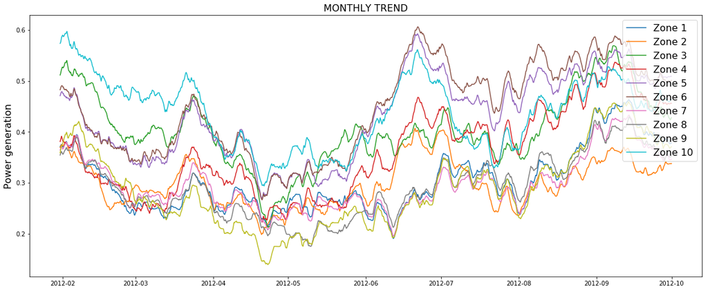

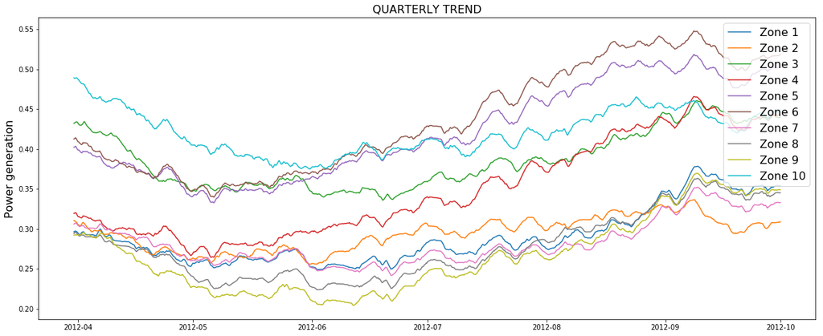

```python
for trend in trends.keys():
    plt.title(trend.upper() + ' TREND', fontdict=FONT)
    plt.ylabel('Power generation', fontdict=FONT)
    for zID in np.unique(task01.ZONEID):
        plt.plot(task01[task01.ZONEID == zID].TARGETVAR.rolling(trends[trend]).mean(),
                 label='Zone {}'.format(zID))
    plt.legend(loc=1, prop={'size': FONT['size']})
    plt.show()
```

> Daily, weekly and monthly power generation trends are quite irregular and difficult to visualize.

### 1.2 Features relationships

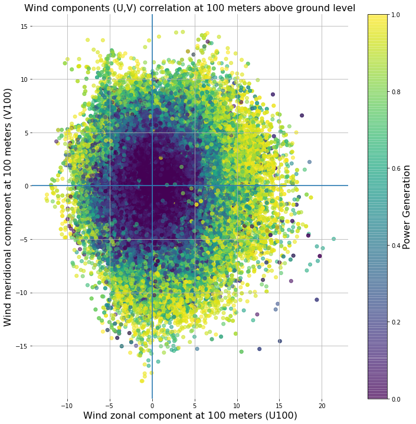

```python
fig, ax = plt.subplots(figsize=(12,12))

sc = plt.scatter(task01.U100, task01.V100, alpha=0.6, c=task01.TARGETVAR)
plt.axvline(x=0.0)
plt.axhline(y=0.0)

cbar = plt.colorbar(sc)
cbar.ax.set_ylabel('Power Generation', fontdict=FONT)

ax.set_frame_on(False)
plt.grid(True)
plt.title('Wind components (U,V) correlation at 100 meters above ground level', fontdict=FONT)
plt.xlabel('Wind zonal component at 100 meters (U100)', fontdict=FONT)
plt.ylabel('Wind meridional component at 100 meters (V100)', fontdict=FONT)
plt.show()
```

> Both 10 and 100 meters records respect the same tendancy. Above is only presented the second graph.

> One can see that the `power generation` is well correlated to `U` and `V` features. When (U,V) are small, the power generation is low, whereas a couple of (U,V) with high values (positive or not) leads to a high power generation.

## 2. Data enrichment

In order to help our algorithms let's compute two new features `wind_10` and `wind_100` that correspond to the norm of the vectors [`U10`,`V10`] and [`U100`, `V100`].

**This data enrichment aims at representing the wind strength, whatever its direction.**

```python
compute_wind_stength = lambda row: pd.Series({'wind_10':norm([row.U10, row.V10]),
                                              'wind_100':norm([row.U100, row.V100])})
```

```python
task01 = task01.merge(task01.apply(compute_wind_stength, axis=1), left_index=True, right_index=True)
```

```python
task01.head()
```

| TIMESTAMP | ZONEID | TARGETVAR | U10 | V10 | U100 | V100 | wind_10 | wind_100 |
| --- | --- | --- | --- | --- | --- | --- | --- | --- |
| 2012-01-01 | 1 | 0.0 | 2.1246 | -2.681966 | 2.86428 | -3.666076 | 3.421530 | 4.652334 |
| 2012-01-01 | 1 | 0.0 | 2.1246 | -2.681966 | 2.86428 | -3.666076 | 3.699120 | 4.551468 |
| 2012-01-01 | 1 | 0.0 | 2.1246 | -2.681966 | 2.86428 | -3.666076 | 3.699120 | 4.551468 |
| 2012-01-01 | 1 | 0.0 | 2.1246 | -2.681966 | 2.86428 | -3.666076 | 5.468725 | 7.102239 |
| 2012-01-01 | 1 | 0.0 | 2.1246 | -2.681966 | 2.86428 | -3.666076 | 4.935621 | 6.324908 |

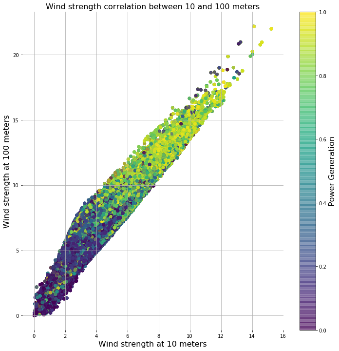

```python
fig, ax = plt.subplots(figsize=(12,12))

sc = plt.scatter(task01.wind_10, task01.wind_100, alpha=0.6, c=task01.TARGETVAR)

cbar = plt.colorbar(sc)
cbar.ax.set_ylabel('Power Generation', fontdict=FONT)

ax.set_frame_on(False)
plt.grid(True)
plt.title('Wind strength correlation between 10 and 100 meters', fontdict=FONT)
plt.xlabel('Wind strength at 10 meters', fontdict=FONT)
plt.ylabel('Wind strength at 100 meters', fontdict=FONT)
plt.show()
```

> As expected the wind farm power generation is highly correlated to the wind strength (color scale).

> From the graph above one can see that the wind strength at 10 meters is also linearly correlated to the 100's. It means that the information contained in columns `wind_X` are quite redundant.

## 3. Regressors exploration

In this section we are trying to use different regressors to predict the power production from the features detailed above.

Here we are doing the following hypothesis: **records are time independant** .

> It means that all weather measurements done in a wind farm are independants from each others.

```python
features = ['ZONEID', 'U10', 'V10', 'U100', 'V100', 'wind_10', 'wind_100']

X = task01[features]
y = task01['TARGETVAR']

del task01
```

**Scaling**:

This step is essential for non tree-based algorithms.

```python
from sklearn.preprocessing import StandardScaler

scaler = StandardScaler()
X_std = scaler.fit_transform(X, y)

del X
```

**Train/test split**:

As we do not have the `POWER GENERATION` values for the given test set, we generate below a new one from the given data. So we are able to train and evaluate by ourselves our algorithms.

```python
from sklearn.model_selection import train_test_split

X_train, X_test, y_train, y_test = train_test_split(X_std, y, test_size=0.30, random_state=42)
```

### 3.1 Tree-based regressors

As trees are estimators that have an easy to catch internal logic, we will mainly focus on them in this subsection.

- First we are testing single tree-based regressors:
  - Decision Tree
  - ExtraTree

```python
from sklearn.model_selection import cross_val_score

def return_CV_scores(regressor, CV=10):
    scores = cross_val_score(regressor, X_train, y_train, cv=CV, n_jobs=-1)
    mean =  scores.mean()
    std = scores.std()
    print('Scores statistics:\n\tMean:', mean)
    print('\tStd:', std)
    return {'mean' : mean, 'std' : std}
```

Each algorithm performance is stored in the `regressors` dictionnary initialized below:

```python
regressors={}
```

#### 3.1.1 Decision Tree Regressor

```python
from sklearn.tree import DecisionTreeRegressor

DT_reg = DecisionTreeRegressor(random_state=42)
```

```python
%%time
regressors['DT_reg'] = return_CV_scores(DT_reg)
```

```
Scores statistics:
	Mean: 0.9640268508890679
	Std: 0.0020147564701418074
CPU times: user 906 ms, sys: 90.3 ms, total: 996 ms
Wall time: 23.1 s
```

#### 3.1.2 ExtraTree Regressor

```python
from sklearn.tree import ExtraTreeRegressor

ExtraT_reg = ExtraTreeRegressor(random_state=42)
```

```python
%%time
regressors['ExtraT_reg'] = return_CV_scores(ExtraT_reg)
```

```
Scores statistics:
	Mean: 0.9199060945654812
	Std: 0.022844793457442683
CPU times: user 968 ms, sys: 100 ms, total: 1.07 s
Wall time: 7.32 s
```

### 3.2 Ensemble Regressors

In this subsection we are exploring ensemble learning methods, still based on tree regressors:

- Random Forest
- AdaBoost
- Gradient Boosting
- ExtraTrees

#### 3.2.1 Random Forest Regressor

*"A __random forest__ is a meta estimator that fits a number of classifying decision trees on various sub-samples of the dataset and use averaging to improve the predictive accuracy and control over-fitting. The sub-sample size is always the same as the original input sample size but the samples are drawn with replacement if bootstrap=True (default)."* http://scikit-learn.org/stable/modules/ensemble.html#forest

```python
from sklearn.ensemble import RandomForestRegressor

RF_reg = RandomForestRegressor(random_state=42, n_jobs=-1)
```

```python
%%time
regressors['RF_reg'] = return_CV_scores(RF_reg)
```

```
Scores statistics:
	Mean: 0.972037986957306
	Std: 0.000911276483045163
CPU times: user 1.11 s, sys: 150 ms, total: 1.26 s
Wall time: 2min 43s
```

#### 3.2.2 AdaBoost Regressor

*" An __AdaBoost regressor__ is a meta-estimator that begins by fitting a regressor on the original dataset and then fits additional copies of the regressor on the same dataset but where the weights of instances are adjusted according to the error of the current prediction. As such, subsequent regressors focus more on difficult cases. "* http://scikit-learn.org/stable/modules/ensemble.html#adaboost

```python
from sklearn.ensemble import AdaBoostRegressor

AdaB_reg = AdaBoostRegressor(DT_reg, random_state=42)
```

```python
%%time
regressors['AdaB_reg'] = return_CV_scores(AdaB_reg)
```

```
Scores statistics:
	Mean: 0.9982089990082221
	Std: 0.0005743280991173982
CPU times: user 1.84 s, sys: 275 ms, total: 2.11 s
Wall time: 18min 58s
```

#### 3.2.3 Gradient Boosting Regressor

*" __Gradient Boosting__ builds an additive model in a forward stage-wise fashion; it allows for the optimization of arbitrary differentiable loss functions. In each stage a regression tree is fit on the negative gradient of the given loss function. "* http://scikit-learn.org/stable/modules/ensemble.html#gradient-boosting

```python
from sklearn.ensemble import GradientBoostingRegressor

GradB_reg = GradientBoostingRegressor(random_state=42)
```

```python
%%time
regressors['GradB_reg'] = return_CV_scores(GradB_reg)
```

```
Scores statistics:
	Mean: 0.7010655891241814
	Std: 0.002341218137780415
CPU times: user 1.29 s, sys: 188 ms, total: 1.48 s
Wall time: 6min 33s
```

#### 3.2.4 ExtraTrees Regressor

An **ExtraTrees regressor** is *" a meta estimator that fits a number of randomized decision trees (a.k.a. extra-trees) on various sub-samples of the dataset and use averaging to improve the predictive accuracy and control over-fitting."* http://scikit-learn.org/stable/modules/ensemble.html#forest

```python
from sklearn.ensemble import ExtraTreesRegressor

ExtraTs_reg = ExtraTreesRegressor(random_state=42, n_jobs=-1)
```

```python
%%time
regressors['ExtraTs_reg'] = return_CV_scores(ExtraTs_reg)
```

```
Scores statistics:
	Mean: 0.9691191963386083
	Std: 0.002258115570142181
CPU times: user 1.02 s, sys: 103 ms, total: 1.13 s
Wall time: 58.8 s
```

### 3.3 Exploring other regressors

This third subsection aims at exploring other algorithms (non tree-based). It is usually a good practice to explore algorithms with very different internal mecanisms to see how they perform on the given data. If all the regressors would have been less performant, we could have done an ensemble learning method like *bagging* to combine the strengths of each of them.

We only test the following regressors:

- K-nearest neighbors
- Mutli-layer Perceptron (from sklearn)

#### 3.3.1 K-nearest neighbors

*"The target is predicted by local interpolation of the targets associated of the nearest neighbors in the training set."* http://scikit-learn.org/stable/modules/neighbors.html#regression

```python
from sklearn.neighbors import KNeighborsRegressor

KNN_reg = KNeighborsRegressor(algorithm='kd_tree',
                              n_neighbors=5)
```

```python
%%time
regressors['KNN_reg'] = return_CV_scores(KNN_reg)
```

```
Scores statistics:
	Mean: 0.8093433355162011
	Std: 0.0020317485791205053
CPU times: user 913 ms, sys: 117 ms, total: 1.03 s
Wall time: 18.8 s
```

#### 3.3.2 Multi-layer Perceptron regressor

*Class __MLPRegressor__ implements a multi-layer perceptron (MLP) that trains using backpropagation with no activation function in the output layer, which can also be seen as using the identity function as activation function. Therefore, it uses the square error as the loss function, and the output is a set of continuous values.* http://scikit-learn.org/stable/modules/neural_networks_supervised.html#regression

```python
from sklearn.neural_network import MLPRegressor

MLP_reg = MLPRegressor(hidden_layer_sizes=(20,),
                       activation='relu',
                       solver='lbfgs',
                       verbose=True,
                       random_state=42)
```

```python
%%time
regressors['MLP_reg'] = return_CV_scores(MLP_reg)
```

```
Scores statistics:
	Mean: 0.6830947548705786
	Std: 0.00451099970032423
CPU times: user 1.61 s, sys: 251 ms, total: 1.86 s
Wall time: 9min 46s
```

```python
from sklearn.neural_network import MLPRegressor

MLP_reg50 = MLPRegressor(hidden_layer_sizes=(50,),
                       activation='relu',
                       solver='lbfgs',
                       verbose=True,
                       random_state=42)
```

```python
%%time
regressors['MLP_reg50'] = return_CV_scores(MLP_reg50)
```

```
Scores statistics:
	Mean: 0.714409606738151
	Std: 0.002370399287731535
CPU times: user 2.26 s, sys: 381 ms, total: 2.64 s
Wall time: 17min 39s
```

## 4. Understanding predictions

After having tested several regressors, here is a quick view of the performances:

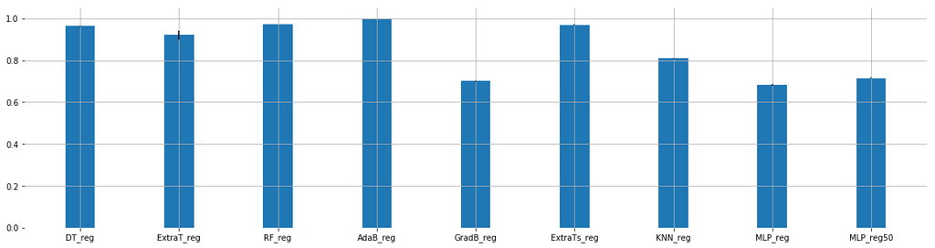

```python
regressors_labels = [r for r in regressors.keys()]
regressors_means = [regressors[r]['mean'] for r in regressors.keys()]
regressors_stds = [regressors[r]['std'] for r in regressors.keys()]


fig, ax = plt.subplots(figsize=(20,5))

idx = np.arange(len(regressors_labels))
plt.bar(idx, regressors_means, width=0.3, yerr=regressors_stds)
plt.xticks(idx, regressors_labels)

ax.set_frame_on(False)
plt.grid(True)

plt.show()
```

Each regressor has some strengths and weaknesses. At this point the client can choose which algorithm fits the best his needs. It can be the speed, the scalability, the robustness... The client can also choose a combinaison of regressors.

In this specific work we continue with the Decision Tree regressor, for the following reasons:

- Decision Trees are estimators that have an **internal logic easy to catch**. The user can understand each prediction by following the tree architecture built during the training process.
- Decision Trees can also explain **features importance** which can be very useful when the data is costly to produce: the user knows which feature really matters for the regressor.
- The decision tree regressor `DT_reg` used above returned quite good results (score above 96%), for a modest processing cost (the cross validated training lasts less than 25s with 10 folds).

### 4.1 Focus on the Decision Tree

#### 4.1.1 Features importance

Features importance is a step that allow the user to understand which features are mainly considerated for the regression. Scores given to each feature can vary a lot between regressors.

```python
DT_reg.fit(X_train, y_train)

print('Features importance:')
for score, feature in sorted(zip(DT_reg.feature_importances_, features), reverse=True):
    print('\t',feature, "%.2f" % score, '%')
```

```
Features importance:
	 wind_100 0.27 %
	 V100 0.24 %
	 U100 0.24 %
	 ZONEID 0.10 %
	 U10 0.08 %
	 V10 0.06 %
	 wind_10 0.01 %
```

Lines above describe our **Decision Tree** features importance.

> During its training process the **Decision Tree** splits samples on their features to order them within different divisions. The decision tree tries to minimize the inner entropy and to maximize the entropy between two branches of a split. **The sooner the split in the tree architecture, the more important is the feature**.

> The wind strength at 100 meters is the feature that influences the most the power generation. Then come the wind components U and V at 100 meters.

#### 4.1.2 Parameters Fine tuning

Let's show how to fine tune our model based on the example of the `max_depth` parameter.

```python
maxdepth = 50

DT_error=[]
DT_processing_time = []

for depth in range(1, maxdepth):
    t0 = time()
    DT_reg = DecisionTreeRegressor(max_depth=depth, random_state=42)
    DT_reg.fit(X_train, y_train)
    DT_error.append(1-DT_reg.score(X_test, y_test))
    DT_processing_time.append(time()-t0)
```

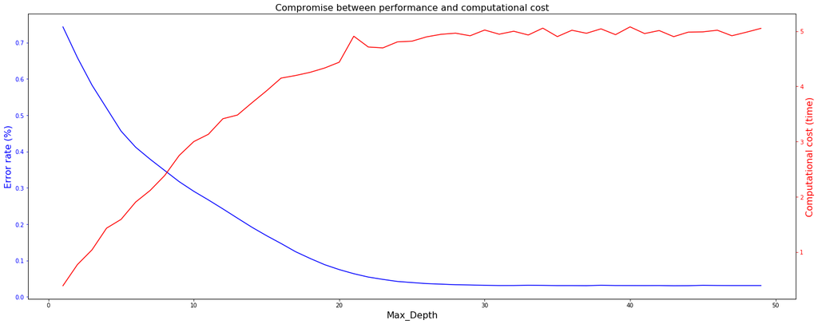

```python
fig, ax1 = plt.subplots()
plt.title('Compromise between performance and computational cost',
          fontdict=FONT)

ax1.plot(range(1, maxdepth), DT_error, 'b-')
ax1.set_xlabel('Max_Depth', fontdict=FONT)


ax1.set_ylabel('Error rate (%)', color='b', fontdict=FONT)
ax1.tick_params('y', colors='b')

ax2 = ax1.twinx()
ax2.plot(range(1, maxdepth), DT_processing_time, 'r')
ax2.set_ylabel('Computational cost (time)', color='r', fontdict=FONT)
ax2.tick_params('y', colors='r')

fig.tight_layout()

plt.show()
```

> The graph above illustrates the compromise between the computational time and the error rate. Here we are only considering a single decision tree hyper-parameter: the `max_depth`. Algorithms can have five or ten hyper-parameters. This fine-tuning step in a machine learning project aims at choosing the best parameters combinaison to fit project needs.

> In order to fine-tune the algorithm hyper-parameters without overfitting on the test set, we should have used a **validation set**. But in this specific work we will stay pragmatic and keep default parameters as they perform very well on the data. On a more complex project a **grid-search** could have been necessary to explore more combinaisons of the algorithm hyper-parameters.

## 5. Conclusion and Prediction simulation

**Conclusion**:

- The **goal** of this work was to **predict the power generation** for each of the ten wind farms, **given the weather forecast** (ie. the wind zonal and meridional components at 10 and 100 meters).
- We tried different regressors to finally choose a simple **Decision Tree regressor** as it performed very well on the data.

**Prediction**:

- The last step is to **simulate a real power production prediction** on the test set (ie. on data that the algorithm has never seen during the training process):

```python
power_generation_prediction = DT_reg.predict(X_test)  # stores predicted values
```

```python
print('Prediction score with the Decision Tree regressor %.2f' % DT_reg.score(X_test, y_test) + '%')
```

```
Prediction score with the Decision Tree regressor 0.97%
```

> As expected, the decision tree regressor `DT_reg` performed well on new data.

Thanks [Craft AI](http://www.craft.ai/) for this nice and clean dataset discovery !